# Info 201 Survey Analysis

The Team (AE5)

2/20/2017

### Summary Statistics Description

This gives a distribution of the programming experience of the corresponding to the number of students in each category:

[output not shown]

This gives a similar distribution to the table above, but instead it shows the distribution of experience when it comes to command line programming.

| Command-Line Experience | Number of People |
| --- | --- |
| Expert user | 4 |
| Intermediate user | 33 |
| Never used it | 59 |
| Used it a few times | 47 |

Here we see that there is no direct correlations between the distributions of the two types of programming.

### Relationship between Programming Experience, Coffee Consumption and Operating Systems

By taking a look at some specific parts of the survey results, we can analyze relationships between the inputs. There were 143 recorded entries from students enrolled into the course. In the bar graph below, the level of programming experience is shown in relation to the total cups of coffee drank per day and type of operating system in use. Programming experience is classified in intervals of lots of experience with a programming language, moderate experience with a programming language, experimentation with simple programming, or never previously writing code. The height of each bar is set by the total number of coffee cups drank per day and the colors within the bars represent the operating systems students used.

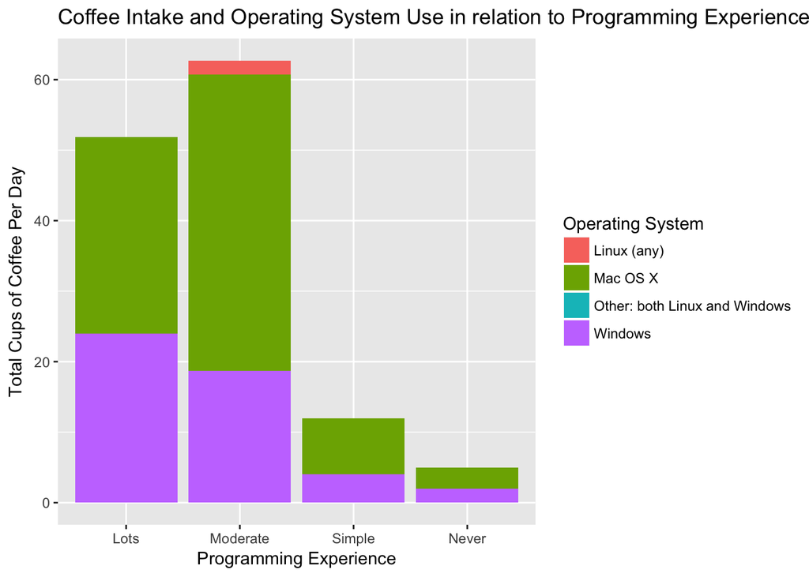

### Programming Experience Details

Previously we looked at the level of programming experience and how it’s related to coffee intake and operating systems. Now we can further analyze the programming experience Info 201 students had before this course. The visual below represents various types of programming platforms and how they tie together to make up the overall experience of students. The axises of the graph show Command Line experience and Markdown experience while the shapes represent R Language experience and colors represent Version Control experience. The input for each of these platforms was recorded on a scale of expert user, intermediate user, no previous use, or using it a few times; with R language as an exception as no student identified themselves as an expert user.

We can now move on to observing some of the patterns present in the plot below. Starting with the colors of the data points, which represent Version Control Experience, we can clearly see that there is a high amount of blue and purple points. This translates to the majority of students stating they have used Version Control a few times or not at all (37 few times users and 90 users with no experience). There’s a small amount of green points and only a few red points, meaning not many students were experienced with Version Control prior to the course; only 2 expert users and 14 intermediate users. Taking a look at the shapes of the points, we can see a similar pattern where most of the students indicated they had little to no experience with R language; 13 users with few times use, 128 users that had never used it before compared to 0 expert users and 2 intermediate users. The distribution itself shows a bit more spread, meaning students had a higher deviation of experience with Command Line and Markdown. There were much more individuals who answered they were an intermediate or expert user with command line. 4 students indicated they were experts with command line and 33 said they were intermediate users. Markdown seemed to follow the trend of Version Control and R: 2 students who identified as expert Markdown users and 5 as intermediate Markdown users. The amount of experienced users in Command Line is much more than the other three platforms.

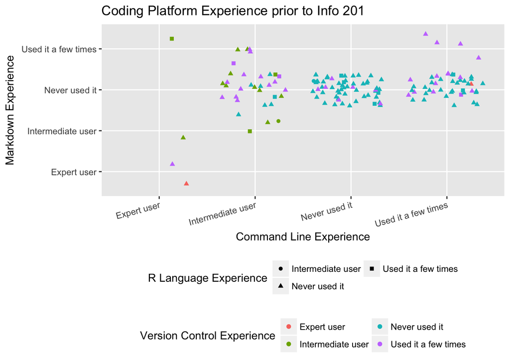

Using this visual is a good tool to understand the details of students’ programming experience prior to enrolling in Info 201. We can see that the majority of students had little to no experience with the languages taught in Info 201, with an emphasis on Version Control, R, and Markdown. The trend with Command Line showed some more experience spread across the distribution but there was still a dense area of points near the less experienced intervals.